# PCIT-CoS-Waitlist RCT Paper 1: Observed maternal negativity (NICHD)

Nancy Briggs

06 June 2022

### Observed maternal negativity (NICHD)

Output run on 2022-06-10

#### Descriptives

Raw Data

| group | time | n | mean | sd | median | min | max |
| --- | --- | --- | --- | --- | --- | --- | --- |
| 1 | 1 | 29 | 6.810 | 2.332 | 6.0 | 5 | 14 |
| 1 | 2 | 21 | 5.286 | 0.561 | 5.0 | 5 | 7 |
| 1 | 3 | 16 | 5.438 | 0.814 | 5.0 | 5 | 8 |
| 2 | 1 | 28 | 7.536 | 2.487 | 7.5 | 5 | 12 |
| 2 | 2 | 12 | 6.917 | 2.151 | 6.5 | 5 | 11 |
| 2 | 3 | 4 | 7.250 | 2.217 | 7.0 | 5 | 10 |
| 3 | 1 | 27 | 7.467 | 2.142 | 7.0 | 5 | 12 |
| 3 | 2 | 21 | 6.676 | 1.721 | 6.0 | 5 | 11 |
| 3 | 3 | 0 | NaN | NA | NA | Inf | -Inf |

Note:  
One person the Waitlist has a value at Follow Up. It has been set to missing.

Log Transformed Data

| group | time | n | mean | sd | median | min | max |
| --- | --- | --- | --- | --- | --- | --- | --- |
| 1 | 1 | 29 | 1.871 | 0.299 | 1.792 | 1.609 | 2.639 |
| 1 | 2 | 21 | 1.660 | 0.098 | 1.609 | 1.609 | 1.946 |
| 1 | 3 | 16 | 1.684 | 0.133 | 1.609 | 1.609 | 2.079 |
| 2 | 1 | 28 | 1.968 | 0.327 | 2.013 | 1.609 | 2.485 |
| 2 | 2 | 12 | 1.892 | 0.297 | 1.869 | 1.609 | 2.398 |
| 2 | 3 | 4 | 1.946 | 0.307 | 1.936 | 1.609 | 2.303 |
| 3 | 1 | 27 | 1.971 | 0.287 | 1.946 | 1.609 | 2.485 |
| 3 | 2 | 21 | 1.869 | 0.243 | 1.792 | 1.609 | 2.398 |
| 3 | 3 | 0 | NaN | NA | NA | Inf | -Inf |

Note:  
One person the Waitlist has a value at Follow Up. It has been set to missing.  
<sup>1</sup> Data are log transofrmed because residuals from an analysis of the raw data violated assumptions in the model.

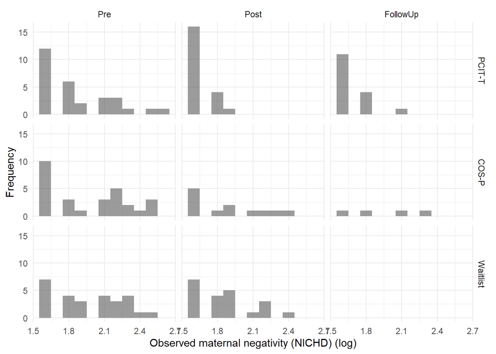

#### Model & Results

A linear mixed model with random effect for individual and fixed effects of group, time and the interaction was run *on the log-transformed data*. Estimated marginal means were obtained, and contrasts specified to test Hypothesis 1 and Hypothesis 2.

```
## fixed-effect model matrix is rank deficient so dropping 1 column / coefficient
```

This is the ANOVA table for the model. p-values are likelihood ratio tests for adding the new term to the model just before. A p-value <0.05 indicates that adding that term results in better model fit. The most important p-value is the interaction p-value. Here, there is evidence that the pattern of change over time is different between the groups (p=0.035).

```
## refitting model(s) with ML (instead of REML)
```

|  | Effect | npar | AIC | BIC | logLik | deviance | Chisq | Df | Pr(>Chisq) |
| --- | --- | --- | --- | --- | --- | --- | --- | --- | --- |
| result0 | Intercept | 3 | 35.179 | 44.367 | -14.589 | 29.179 | NA | NA | NA |
| result1 | Group | 5 | 29.080 | 44.393 | -9.540 | 19.080 | 10.099 | 2 | 0.006 |
| result2 | Time | 7 | 20.900 | 42.338 | -3.450 | 6.900 | 12.180 | 2 | 0.002 |
| result3 | Group*Time | 10 | 18.295 | 48.921 | 0.852 | -1.705 | 8.605 | 3 | 0.035 |

```r
summary(result3)
```

```
## Linear mixed model fit by REML. t-tests use Satterthwaite's method [
## lmerModLmerTest]
## Formula: outcome ~ group * time + (1 | id)
##    Data: dat
##
## REML criterion at convergence: 29.6
##
## Scaled residuals:
##      Min       1Q   Median       3Q      Max
## -1.77636 -0.66571  0.01858  0.54923  2.85211
##
## Random effects:
##  Groups   Name        Variance Std.Dev.
##  id       (Intercept) 0.04315  0.2077
##  Residual             0.03146  0.1774
## Number of obs: 158, groups:  id, 86
##
## Fixed effects:
##               Estimate Std. Error        df t value Pr(>|t|)
## (Intercept)    1.87148    0.05072 104.88648  36.897  < 2e-16 ***
## group2         0.08748    0.07212 106.51721   1.213 0.227817
## group3         0.11092    0.07282 106.55702   1.523 0.130670
## time2         -0.20872    0.05298  64.37481  -3.939 0.000204 ***
## time3         -0.15350    0.05872  65.98763  -2.614 0.011080 *
## group2:time2   0.22622    0.08678  72.38589   2.607 0.011092 *
## group3:time2   0.08784    0.07576  65.26236   1.160 0.250472
## group2:time3   0.29376    0.12669  78.70425   2.319 0.023001 *
## ---
## Signif. codes:  0 '***' 0.001 '**' 0.01 '*' 0.05 '.' 0.1 ' ' 1
##
## Correlation of Fixed Effects:
##             (Intr) group2 group3 time2  time3  grp2:2 grp3:2
## group2      -0.703
## group3      -0.697  0.490
## time2       -0.404  0.284  0.281
## time3       -0.364  0.256  0.254  0.409
## group2:tim2  0.246 -0.362 -0.172 -0.611 -0.250
## group3:tim2  0.282 -0.199 -0.415 -0.699 -0.286  0.427
## group2:tim3  0.169 -0.259 -0.118 -0.189 -0.464  0.294  0.132
## fit warnings:
## fixed-effect model matrix is rank deficient so dropping 1 column / coefficient
```

#### Estimated Means & Change

Estimated means for each Treatment and Time are presented. In addition, within-group change between time points is presented with 95% CIs.

##### Group mean difference at each timepoint

Effect sizes all calculated by the pooled T1 SD of the outcome. Adjusted p-value from Bonferroni correction.

Group Differences at Each Time Point

| Group Difference | Time | Mean | SE | t | p | adj p | Lower CL | Upper CL | Effect Size | Lower CL | Upper CL |
| --- | --- | --- | --- | --- | --- | --- | --- | --- | --- | --- | --- |
| 1 - 2 | 1 | -0.087 | 0.072 | -1.213 | 0.448 | 0.683 | -0.259 | 0.084 | -0.279 | -0.834 | 0.164 |
| 1 - 3 | 1 | -0.111 | 0.073 | -1.523 | 0.284 | 0.392 | -0.284 | 0.062 | -0.354 | -0.958 | 0.124 |
| 2 - 3 | 1 | -0.023 | 0.073 | -0.320 | 0.945 | 1.000 | -0.197 | 0.150 | -0.075 | -0.541 | 0.399 |
| 1 - 2 | 2 | -0.314 | 0.091 | -3.451 | 0.002 | 0.002 | -0.529 | -0.099 | -1.002 | -1.905 | -0.524 |
| 1 - 3 | 2 | -0.199 | 0.081 | -2.467 | 0.039 | 0.045 | -0.390 | -0.008 | -0.635 | -1.296 | -0.160 |
| 2 - 3 | 2 | 0.115 | 0.091 | 1.261 | 0.420 | 0.628 | -0.101 | 0.331 | 0.367 | -0.200 | 1.114 |
| 1 - 2 | 3 | -0.381 | 0.129 | -2.950 | 0.010 | 0.011 | -0.688 | -0.075 | -1.218 | -2.423 | -0.523 |
| 1 - 3 | 3 | NA | NA | NA | NA | NA | NA | NA | NA | NA | NA |
| 2 - 3 | 3 | NA | NA | NA | NA | NA | NA | NA | NA | NA | NA |

* Effect size scaled by pooled T1 SD  
† ES 95% Bootstrapped Percentile CI limits  
‡ If you want a positive ES (and it is calculated as negative), be sure to switch the signs and positions of the lower and upper CIs.

##### Change within each group

Within-Group Change and Effect Sizes

| Change | Group | Mean | SE | t | p | adj p | Lower CL | Upper CL | Effect Size | Lower CL | Upper CL |
| --- | --- | --- | --- | --- | --- | --- | --- | --- | --- | --- | --- |
| 1 - 2 | 1 | 0.209 | 0.053 | 3.931 | 0.001 | 0.001 | 0.082 | 0.336 | 0.667 | 0.372 | 1.190 |
| 1 - 3 | 1 | 0.153 | 0.059 | 2.607 | 0.029 | 0.033 | 0.013 | 0.294 | 0.490 | 0.114 | 1.036 |
| 2 - 3 | 1 | -0.055 | 0.061 | -0.905 | 0.639 | 1.000 | -0.201 | 0.091 | -0.176 | -0.668 | 0.257 |
| 1 - 2 | 2 | -0.017 | 0.069 | -0.253 | 0.965 | 1.000 | -0.182 | 0.147 | -0.056 | -0.566 | 0.428 |
| 1 - 3 | 2 | -0.140 | 0.113 | -1.241 | 0.432 | 0.654 | -0.410 | 0.129 | -0.448 | -1.379 | 0.289 |
| 2 - 3 | 2 | -0.123 | 0.116 | -1.055 | 0.545 | 0.883 | -0.400 | 0.155 | -0.392 | -1.323 | 0.383 |
| 1 - 2 | 3 | 0.121 | 0.054 | 2.227 | 0.073 | 0.087 | -0.009 | 0.251 | 0.386 | 0.048 | 0.865 |
| 1 - 3 | 3 | NA | NA | NA | NA | NA | NA | NA | NA | NA | NA |
| 2 - 3 | 3 | NA | NA | NA | NA | NA | NA | NA | NA | NA | NA |

* Effect size scaled by pooled T1 SD  
† ES 95% Bootstrapped Percentile CI limits  
‡ If you want a positive ES (and it is calculated as negative), be sure to switch the signs and positions of the lower and upper CIs.

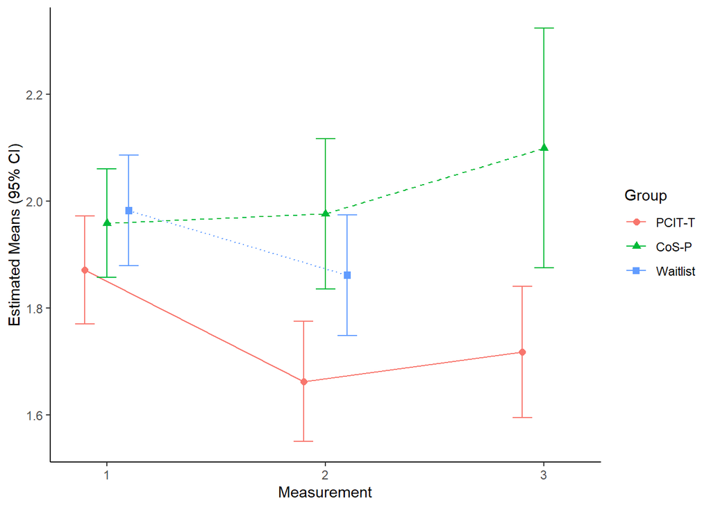

#### Hypothesis 1

We hypothesize that from baseline (‘T1’) to post-treatment/waitlist (‘T2’) there will be a gradient effect, whereby parent-child dyads who receive PCIT-T will show the greatest gains and parent-child dyads who receive no treatment will show the least gains. For the outcome, then, the null hypothesis is:

$H_0: \text {mean change}(\text{PCIT-T}) = \text {mean change}(\text{CoS-P}) = \text {mean change}(\text{Waitlist})$ $H_A: \text {mean change}(\text{PCIT-T}) > \text {mean change}(\text{CoS-P}) > \text {mean change}(\text{Waitlist})$

This is a joint hypothesis test.

First, confirming that the ordering of the means is as hypothesized:

```
## group = 1:
##  contrast estimate     SE   df t.ratio p.value
##  1 - 2      0.2087 0.0531 75.0   3.931  0.0005
##  1 - 3      0.1535 0.0589 76.7   2.607  0.0292
##  2 - 3     -0.0552 0.0610 72.1  -0.905  0.6389
##
## group = 2:
##  contrast estimate     SE   df t.ratio p.value
##  1 - 2     -0.0175 0.0691 88.2  -0.253  0.9653
##  1 - 3     -0.1403 0.1131 93.0  -1.241  0.4325
##  2 - 3     -0.1228 0.1164 84.0  -1.055  0.5445
##
## group = 3:
##  contrast estimate     SE   df t.ratio p.value
##  1 - 2      0.1209 0.0543 76.8   2.227  0.0730
##  1 - 3      nonEst     NA   NA      NA      NA
##  2 - 3      nonEst     NA   NA      NA      NA
##
## Degrees-of-freedom method: kenward-roger
## P value adjustment: tukey method for comparing a family of 3 estimates
```

scores decreased for the PCITT group from Baseline to post (0.208), and increased for COSP (-.0175).

```
##   (Intercept) group2 group3 time2 time3 group2:time2 group3:time2 group2:time3
## 1           0      0      0     0     0           -1            0            0
## 2           0      0      0     0     1            0            1            0
```

```
##
##   General Linear Hypotheses
##
## Linear Hypotheses:
##        Estimate
## 1 == 0 -0.22622
## 2 == 0 -0.06565
##
## Global Test:
##       F DF1 DF2  Pr(>F)
## 1 4.385   2 148 0.01413
```

pvalue<0.05. We do have evidence that there is a difference in the change over from Baseline to Post amongst the groups.

#### Hypothesis 2

There will be a gradient of size of change from T2 to T3 such that the change in the PCIT-T group > the change in the CoS-P group. This isn’t really a gradient; it’s just 1 hypothesis.

First, the change in PCITT and COSP from time 2 to time 3:

```
## group = 1:
##  contrast estimate     SE   df t.ratio p.value
##  1 - 2      0.2087 0.0531 75.0   3.931  0.0005
##  1 - 3      0.1535 0.0589 76.7   2.607  0.0292
##  2 - 3     -0.0552 0.0610 72.1  -0.905  0.6389
##
## group = 2:
##  contrast estimate     SE   df t.ratio p.value
##  1 - 2     -0.0175 0.0691 88.2  -0.253  0.9653
##  1 - 3     -0.1403 0.1131 93.0  -1.241  0.4325
##  2 - 3     -0.1228 0.1164 84.0  -1.055  0.5445
##
## group = 3:
##  contrast estimate     SE   df t.ratio p.value
##  1 - 2      0.1209 0.0543 76.8   2.227  0.0730
##  1 - 3      nonEst     NA   NA      NA      NA
##  2 - 3      nonEst     NA   NA      NA      NA
##
## Degrees-of-freedom method: kenward-roger
## P value adjustment: tukey method for comparing a family of 3 estimates
```

There is not as much change in PCITT(-.055) as in COSP (-.123).

```
##
##   Simultaneous Tests for General Linear Hypotheses
##
## Fit: lmer(formula = outcome ~ group * time + (1 | id), data = dat)
##
## Linear Hypotheses:
##        Estimate Std. Error z value Pr(>|z|)
## 1 == 0  0.06755    0.13082   0.516    0.606
## (Adjusted p values reported -- single-step method)
```

p>0.05, so we do not have enough evidence to suggest that the change from t2 to t3 in PCITT is greater than the change in COSP.

#### Residuals

Assumptions of the model are met when analysing the log-trasformed data.

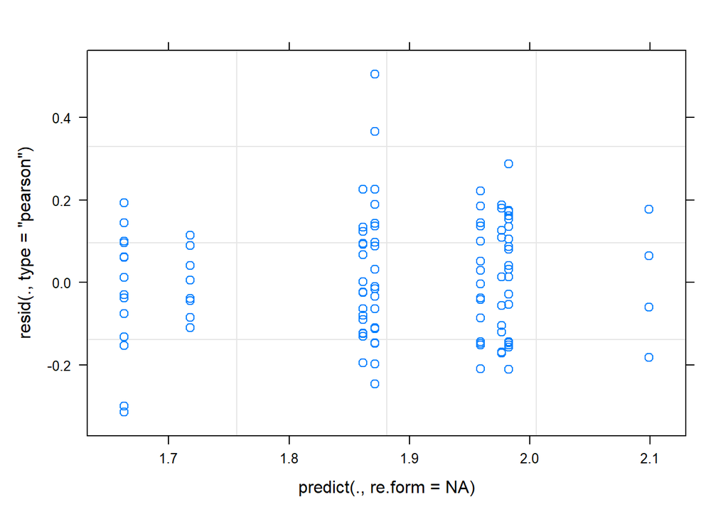

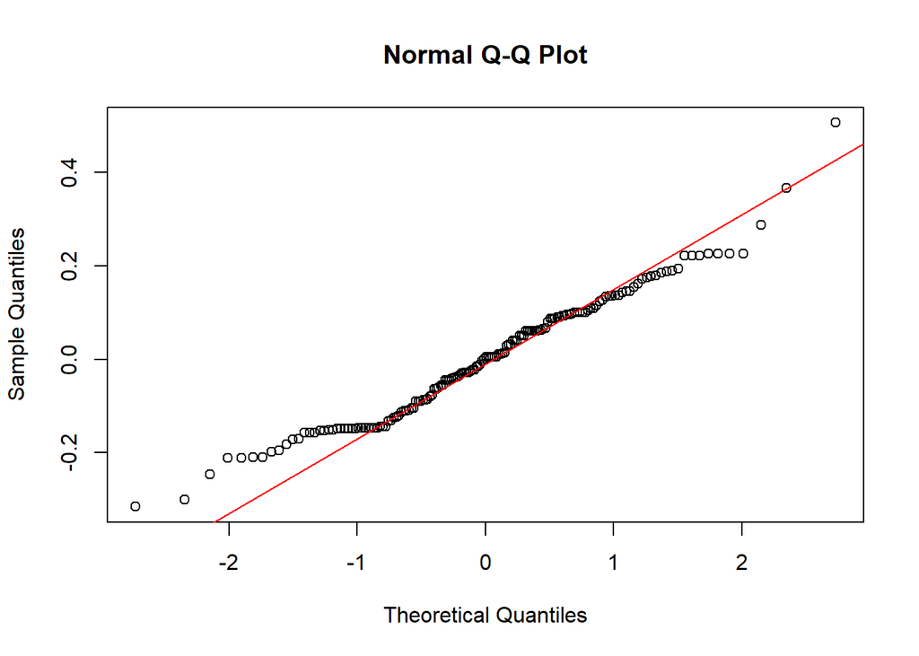

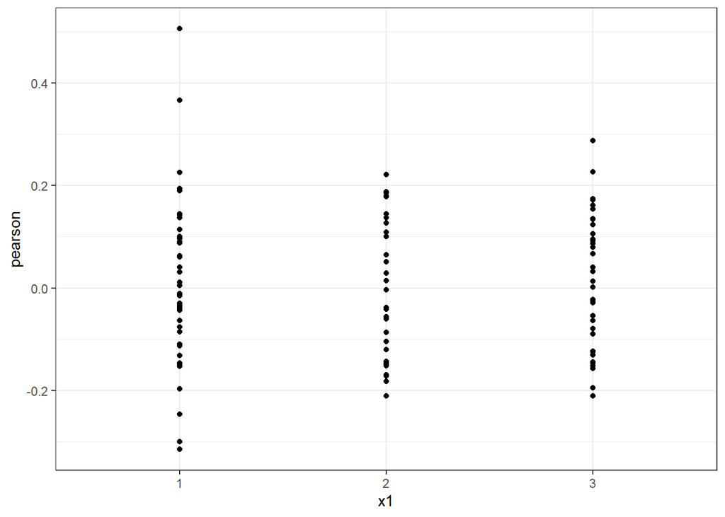

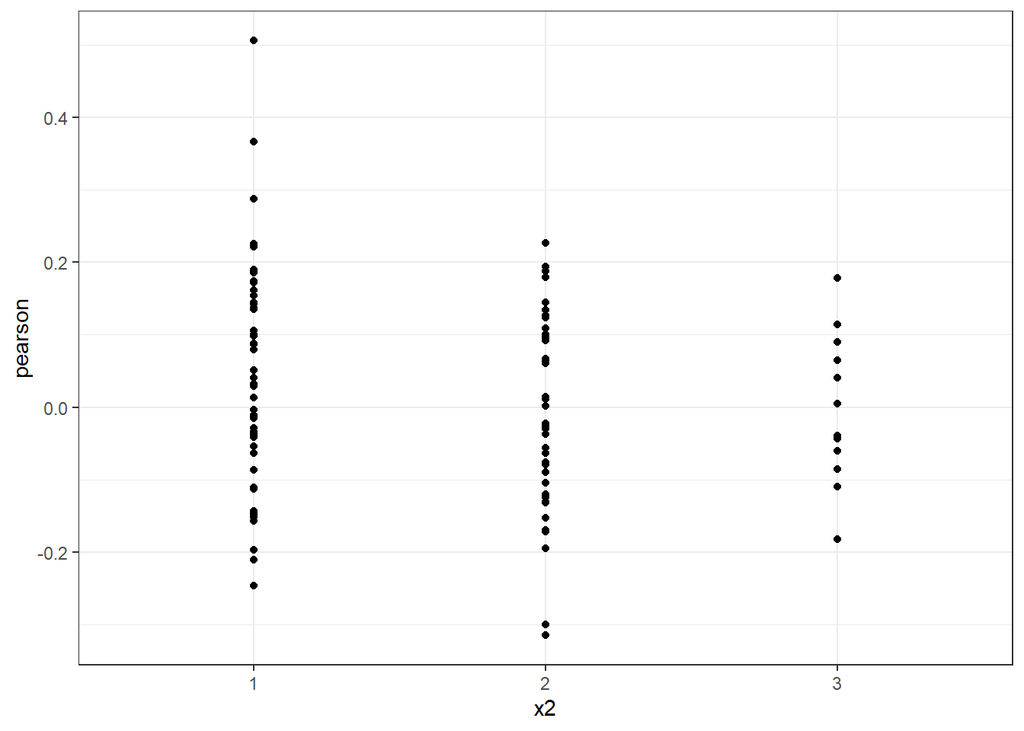

```r
rm(list = ls())
```